# Final Project - Kobe Bryant’s Mamba Mentality Represented By His 2009 Final’s MVP Stats

### Stats Table Flipped Vertically and Used as a Bar Graph

```r
#flips the graph vertically. I want to have the game number as columns, stats as different rows.

kobeLong <- kobeStats %>% #Challenge 3 - pivot_longer
  pivot_longer(cols = shots_made:points, names_to = "categories", values_to = "stats") %>%
  filter(categories != "shooting_accuracy")
```

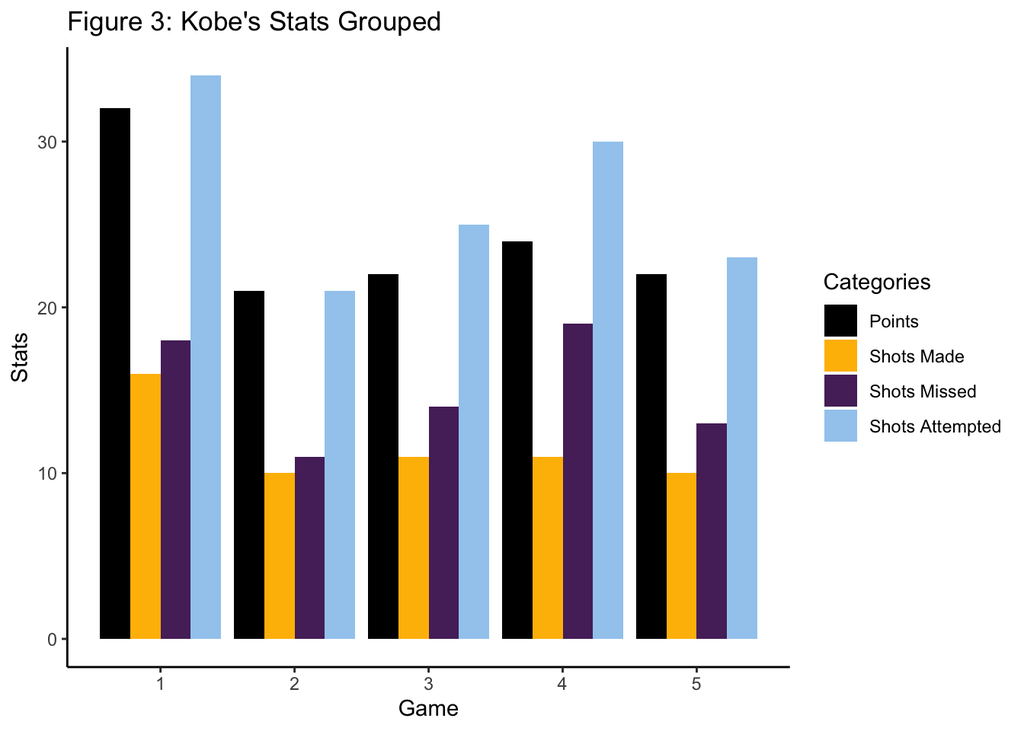

```r
kobeLong %>%
  ggplot(aes(x=game, y = stats))+
  geom_bar(stat = "identity", position = "dodge", aes(fill = categories)) +
  scale_fill_manual(name = "Categories", labels = c("Points", "Shots Made", "Shots Missed", "Shots Attempted"), values=c("black","#FEBC00", "#572B69", "#A2CCEE" )) +
  labs(title="Figure 3: Kobe's Stats Grouped", x= "Game", y="Stats") +
  theme_classic()
```

Figure 3: Form: Group Bar Graph

This figure groups the categories in the first table and displays them in a bar graph format that allows you to see how his statistics changed over the span of these five games. An interesting relationship that could be spotted in this graph is a relationship between Kobe’s shot attempts and his points per game. Ultimately, the more shots that Kobe took, the more points he scored. This connection makes sense given that he averaged a shooting percentage of 43.8 percent according to Figure 1.

### Kobe’s Stats Over the Five Games

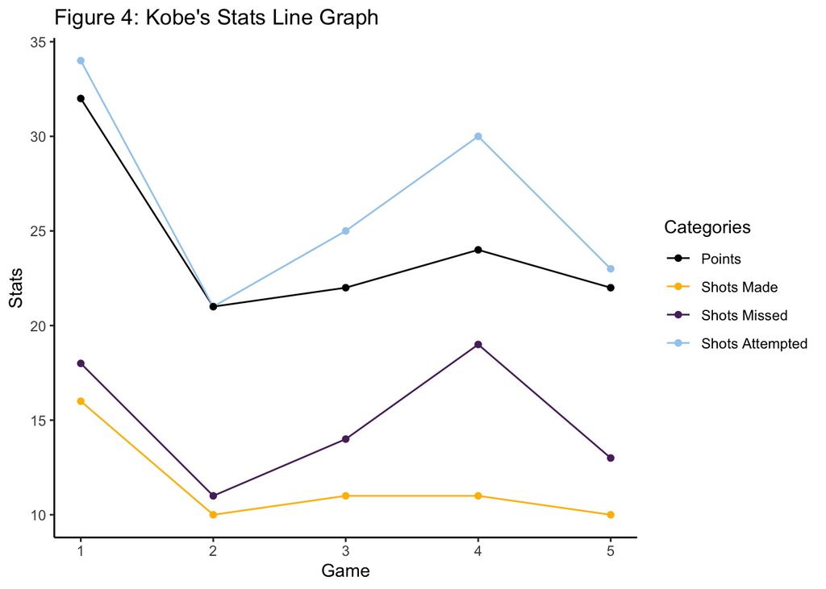

```r
kobeLong %>%
  ggplot(aes(x = game, y = stats, class = categories, color = categories)) +
  geom_line() +
  geom_point() +
  scale_color_manual(name = "Categories", labels = c("Points", "Shots Made", "Shots Missed", "Shots Attempted"), values = c("black","#FEBC00", "#572B69", "#A2CCEE")) +
  labs(title="Figure 4: Kobe's Stats Line Graph", x= "Game", y="Stats") +
  theme_classic()
```

Figure 4: Form: Dotted Line Graph

This graph, similar to Figure 3, shows a visual of the stat categories from Figure 1 over the span of the five games. This graph, however, allows for a much better visual representation of Kobe’s shooting efficiency. You can see a gap between the shots made and the shots missed (lines gold and purple respectively) around games 3-5. The graph also shows why Kobe’s shooting percentage was at its lowest in Game 4; as the light blue line increases (shots attempted), the gold line (shots made) stays within the same range of the rest of the games.

## Discussion

Despite of these challenges, I was able to analyze Kobe’s individual performance to an extent. I believe that this data says more about Kobe’s work ethic and strong mentality rather than his impact on a basketball game. Although we saw a fluctuation of Kobe’s accuracy throughout the five game series, Kobe did not become dicouraged to handle the basketball, and in fact, took on the most challenging shots when it mattered most. We can see Kobe’s killer instinct by taking a look at his shot attempts in fourth quarters. In Game 4 he took 12 out of his 30 total shots in the fourth quarter and overtime, and in Game 5 he took 8 out of his 23 shot attempts in the fourth quarter alone. These were arguably the most important games of the series, because as a team, you want to make sure you are in control of the game’s momentum. Having a 3-1 lead puts a lot of the pressure on the other team to make a historic comeback, but you also don’t want to allow them to have hope for a come back in game 5. Kobe took on the responsibility in the last instances of Game 5 to put away the Orlando Magic and win the title of NBA Champion, as well as his first Finals MVP.

## Additional Pages

I would like to thank Jimmy Rasolosoa for taking intrest in my project and asking to check out my graphs. Even though my project was still in its very earliest stages, Jimmy’s enthusiastic “wooooow” really gave me the push that I needed to move forward with my vision of this project. Thank you Jimmy. I hope that I have made you proud and I hope that Lyon win the Ligue 1 one day.

ESPN. “NBA - National Basketball Association.” ESPN, 14 June 2009, www.espn.com/nba/game/_/gameId/290614019. Accessed 18 May 2023.

“Kobe Bryant Stats - 2009 Finals.” StatMuse, www.statmuse.com/nba/ask/kobe-bryant-stats-2009-finals#:~:text=Kobe%20Bryant%20averaged%2032.4%20points,in%20the%202009%20NBA%20Finals. Accessed 18 May 2023.

Challenge 1: str_detect - used it to create the shooting percentage variable by dividing the amount of shots “H”(hit) and shots “M”(missed).

Challenge 2: inner_join - created the data set “kobeStats” by joining “shotsH” and “shotsM”, which were both data sets in which I filtered for shots hit and shots missed, respectively, off the “KobeMVP” data set, inside of the “shots” column.

Challenge 3: pivot_longer - created a long table in which I created a column called “categories” where all the stat categories were stored (shotsH, shotsM, total_shots, shots_made). I also created another column called stats that counted these stats numerically. I did this in order to create a grouped bar graph to try and create a visual of the stats table.

Bonus: substr - substr is a base function in r that we didn’t cover in class, yet I took the time to experiment with and ultimately incorporate into my project. I used substr to isolate specific strings in the shot description column of “KobeMVP” in order to create my own column that showed the distance of Kobe’s throughout the five game series.